# Summarization and quantitative trait analysis of CNV ranges

Vinicius Henrique da Silva and Ludwig Geistlinger

Animal Breeding and Genomics, Wageningen University & Research, Wageningen, The Netherlands  
Animal Breeding and Genetics, Swedish University of Agricultural Sciences, Uppsala, Sweden  
Netherlands Institute of Ecology (NIOO-KNAW), Wageningen, The Netherlands  
School of Public Health, City University of New York

vinicius.dasilva@wur.nl  
ludwig.geistlinger@sph.cuny.edu

12 July 2019

#### Abstract

The *CNVRanger* package implements a comprehensive tool suite for the analysis of copy number variation (CNV). This includes functionality for summarizing individual CNV calls across a population, assessing overlap with functional genomic regions, and association analysis with gene expression and quantitative phenotypes.

#### Package

CNVRanger 1.1.5

# 1 Introduction

Copy number variation (CNV) is a frequently observed deviation from the diploid state due to duplication or deletion of genomic regions. CNVs can be experimentally detected based on comparative genomic hybridization, and computationally inferred from SNP-arrays or next-generation sequencing data. These technologies for CNV detection have in common that they report, for each sample under study, genomic regions that are duplicated or deleted with respect to a reference. Such regions are denoted as *CNV calls* in the following and will be considered the starting point for analysis with the *CNVRanger* package.

The following figure provides an overview of the analysis capabilities of `CNVRanger`.

[figure not shown]

**(A)** The *CNVRanger* package imports CNV calls from a simple file format into `R`, and stores them in dedicated Bioconductor data structures, and **(B)** implements three frequently used approaches for summarizing CNV calls across a population: *(i)* the CNVRuler procedure that trims region margins based on regional density [Kim et al., 2012](https://doi.org/10.1093/bioinformatics/bts239), *(ii)* the reciprocal overlap procedure that requires sufficient mutual overlap between calls [Conrad et al., 2010](https://doi.org/10.1038/nature08516), and *(iii)* the [GISTIC](http://www.broadinstitute.org/cancer/cga/gistic) procedure that identifies recurrent CNV regions [Beroukhim et al., 2007](https://doi.org/10.1073/pnas.0710052104). **(C)** `CNVRanger` builds on *regioneR* for overlap analysis of CNVs with functional genomic regions, **(D)** implements RNA-seq expression Quantitative Trait Loci (eQTL) analysis for CNVs by interfacing with *edgeR*, and **(E)** interfaces with [PLINK](http://zzz.bwh.harvard.edu/plink) for traditional genome-wide association studies (GWAS) between CNVs and quantitative phenotypes.

The key parts of the functionality implemented in *CNVRanger* were developed, described, and applied in several previous studies:

- Genome-wide detection of CNVs and their association with meat tenderness in Nelore cattle [da Silva et al., 2016](https://doi.org/10.1371/journal.pone.0157711)
- Widespread modulation of gene expression by copy number variation in skeletal muscle [Geistlinger et al., 2018](https://doi.org/10.1038/s41598-018-19782-4)
- CNVs are associated with genomic architecture in a songbird [da Silva et al., 2018](https://doi.org/10.1186/s12864-018-4577-1)

# 2 Applicability and Scope

As described in the above publications, *CNVRanger* has been developed and extensively tested for SNP-based CNV calls as obtained with [PennCNV](https://doi.org/10.1101/gr.6861907). We also tested `CNVRanger` for sequencing-based CNV calls as obtained with [CNVnator](https://doi.org/10.1101/gr.114876.110) (a read-depth approach) or [LUMPY](https://doi.org/10.1186/gb-2014-15-6-r84) (an approach that combines evidence from split-reads and disconcordant read-pairs).

In general, *CNVRanger* can be applied to CNV calls associated with integer copy number states, where we assume the states to be encoded as:

- `0`: homozygous deletion (2-copy loss)
- `1`: heterozygous deletion (1-copy loss)
- `2`: normal diploid state
- `3`: 1-copy gain
- `4`: amplification (>= 2-copy gain)

Note that for CNV calling software that uses a different encoding or that does not provide integer copy number states, it is often possible to (at least approximately) transform the output to a format that is compatible with the input format of *CNVRanger*. See Section 4.1 *Input data format* for details.

*CNVRanger* is designed to work with CNV calls from one tool at a time. See [EnsembleCNV](https://doi.org/10.1093/nar/gkz068) and [FusorSV](https://doi.org/10.1186/s13059-018-1404-6) for combining CNV calls from multiple SNP-based callers or multiple sequencing-based callers, respectively.

*CNVRanger* assumes CNV calls provided as input to be already filtered by quality, using the software that was used for CNV calling, or specific tools for that purpose. *CNVRanger* provides downstream summarization and association analysis for CNV calls, it does not implement functions for CNV calling or quality control. *CNVRanger* is applicable for diploid species only.

# 3 Key functions

| Analysis step | Function |
| --- | --- |
| (A) Input | `GenomicRanges::makeGRangesListFromDataFrame` |
| (B) Summarization | `populationRanges` |
| (C) Overlap analysis | `regioneR::overlapPermTest` |
| (D) Expression analysis | `cnvEQTL` |
| (E) Phenotype analysis | `cnvGWAS` |

Note: we use the `package::function` notation for functions from other packages. For functions from this package and base R functions, we use the function name without preceding package name.

# 4 Reading and accessing CNV data

[figure not shown]

The *CNVRanger* package uses Bioconductor core data structures implemented in the *GenomicRanges* and *RaggedExperiment* packages to represent, access, and manipulate CNV data.

We start by loading the package.

```r
library(CNVRanger)
```

## 4.1 Input data format

In a diploid genome, a single-copy gain in a perfectly pure, homogeneous sample has a copy ratio of 3/2. In log2 scale, this is log2(3/2) = 0.585, and a single-copy loss is log2(1/2) = -1.0.

For demonstration, we consider CNV calls as obtained with [PennCNV](http://penncnv.openbioinformatics.org) from SNP-chip data in a Brazilian cattle breed ([da Silva et al., 2016](https://doi.org/10.1371/journal.pone.0157711)).

Here, we use a data subset and only consider CNV calls on chromosome 1 and 2, for which there are roughly 3000 CNV calls as obtained for 711 samples.

```r
data.dir <- system.file("extdata", package="CNVRanger")
call.file <- file.path(data.dir, "Silva16_PONE_CNV_calls.csv")
calls <- read.csv(call.file, as.is=TRUE)
nrow(calls)
```

```
## [1] 3000
```

```r
head(calls)
```

```
##    chr start    end    NE_id state
## 1 chr1 16947  45013 NE001423     3
## 2 chr1 36337  67130 NE001426     3
## 3 chr1 16947  36337 NE001428     3
## 4 chr1 36337 105963 NE001519     3
## 5 chr1 36337  83412 NE001534     3
## 6 chr1 36337  83412 NE001648     3
```

```r
length(unique(calls[,"NE_id"]))
```

```
## [1] 711
```

## 4.2 Representation as a `GRangesList`

We group the calls by sample ID, resulting in a `GRangesList`. Each element of the list corresponds to a sample, and contains the genomic coordinates of the CNV calls for this sample (along with the copy number state in the `State` metadata column).

```r
grl <- GenomicRanges::makeGRangesListFromDataFrame(calls,
    split.field="NE_id", keep.extra.columns=TRUE)
grl
```

```
## GRangesList object of length 711:
## $NE001357
## GRanges object with 5 ranges and 1 metadata column:
##       seqnames            ranges strand |     state
##          <Rle>         <IRanges>  <Rle> | <integer>
##   [1]     chr1   4569526-4577608      * |         3
##   [2]     chr1 15984544-15996851      * |         1
##   [3]     chr1 38306432-38330161      * |         3
##   [4]     chr1 93730576-93819471      * |         0
##   [5]     chr2 40529044-40540747      * |         3
##   -------
##   seqinfo: 2 sequences from an unspecified genome; no seqlengths
##
## $NE001358
## GRanges object with 1 range and 1 metadata column:
##       seqnames              ranges strand |     state
##          <Rle>           <IRanges>  <Rle> | <integer>
##   [1]     chr1 105042452-105233446      * |         1
##   -------
##   seqinfo: 2 sequences from an unspecified genome; no seqlengths
##
## $NE001359
## GRanges object with 4 ranges and 1 metadata column:
##       seqnames            ranges strand |     state
##          <Rle>         <IRanges>  <Rle> | <integer>
##   [1]     chr1   4569526-4577608      * |         3
##   [2]     chr1 31686841-31695808      * |         0
##   [3]     chr1 93730576-93819471      * |         0
##   [4]     chr2   2527718-2535261      * |         0
##   -------
##   seqinfo: 2 sequences from an unspecified genome; no seqlengths
##
## ...
## <708 more elements>
```

The advantage of representing the CNV calls as a `GRangesList` is that it allows to leverage the comprehensive set of operations on genomic regions implemented in the *GenomicRanges* packages - for instance, sorting of the calls according to their genomic coordinates.

```r
grl <- GenomicRanges::sort(grl)
grl
```

```
## GRangesList object of length 711:
## $NE001357
## GRanges object with 5 ranges and 1 metadata column:
##       seqnames            ranges strand |     state
##          <Rle>         <IRanges>  <Rle> | <integer>
##   [1]     chr1   4569526-4577608      * |         3
##   [2]     chr1 15984544-15996851      * |         1
##   [3]     chr1 38306432-38330161      * |         3
##   [4]     chr1 93730576-93819471      * |         0
##   [5]     chr2 40529044-40540747      * |         3
##   -------
##   seqinfo: 2 sequences from an unspecified genome; no seqlengths
##
## $NE001358
## GRanges object with 1 range and 1 metadata column:
##       seqnames              ranges strand |     state
##          <Rle>           <IRanges>  <Rle> | <integer>
##   [1]     chr1 105042452-105233446      * |         1
##   -------
##   seqinfo: 2 sequences from an unspecified genome; no seqlengths
##
## $NE001359
## GRanges object with 4 ranges and 1 metadata column:
##       seqnames            ranges strand |     state
##          <Rle>         <IRanges>  <Rle> | <integer>
##   [1]     chr1   4569526-4577608      * |         3
##   [2]     chr1 31686841-31695808      * |         0
##   [3]     chr1 93730576-93819471      * |         0
##   [4]     chr2   2527718-2535261      * |         0
##   -------
##   seqinfo: 2 sequences from an unspecified genome; no seqlengths
##
## ...
## <708 more elements>
```

The input file containg CNV calls should necessarily have at least five columns, which will indicate for each call its (i) chromosome, (ii) downstream breakpoint start, (iii) upstream breakpoint, (iv) sample name and the (v) copy number state. Independently of the format of CNV calls (i.e. tab or space delimited), the R object containing these calls should be converted to a `GRangesList`, as described above, in order to be used as input in *CNVRanger* functions.

## 4.3 Representation as a `RaggedExperiment`

An alternative matrix-like representation of the CNV calls can be obtained with the *RaggedExperiment* data class. It resembles in many aspects the *SummarizedExperiment* data class for storing gene expression data as e.g. obtained with RNA-seq.

```r
ra <- RaggedExperiment::RaggedExperiment(grl)
ra
```

```
## class: RaggedExperiment
## dim: 3000 711
## assays(1): state
## rownames: NULL
## colnames(711): NE001357 NE001358 ... NE003967 NE003968
## colData names(0):
```

As apparent from the `dim` slot of the object, it stores the CNV calls in the rows and the samples in the columns. Note that the CN state is now represented as an assay matrix which can be easily accessed and subsetted.

```r
RaggedExperiment::assay(ra[1:5,1:5])
```

```
##                        NE001357 NE001358 NE001359 NE001360 NE001361
## chr1:4569526-4577608          3       NA       NA       NA       NA
## chr1:15984544-15996851        1       NA       NA       NA       NA
## chr1:38306432-38330161        3       NA       NA       NA       NA
## chr1:93730576-93819471        0       NA       NA       NA       NA
## chr2:40529044-40540747        3       NA       NA       NA       NA
```

As with *SummarizedExperiment* objects, additional information for the samples are annotated in the `colData` slot. For example, we annotate the steer weight and its feed conversion ratio (FCR) using simulated data. Feed conversion ratio is the ratio of dry matter intake to live-weight gain. A typical range of feed conversion ratios is 4.5-7.5 with a lower number being more desirable as it would indicate that a steer required less feed per pound of gain.

```r
weight <- rnorm(ncol(ra), mean=1100, sd=100)
fcr <- rnorm(ncol(ra), mean=6, sd=1.5)
RaggedExperiment::colData(ra)$weight <- round(weight, digits=2)
RaggedExperiment::colData(ra)$fcr <- round(fcr, digits=2)
RaggedExperiment::colData(ra)
```

```
## DataFrame with 711 rows and 2 columns
##             weight       fcr
##          <numeric> <numeric>
## NE001357   1144.16      5.27
## NE001358   1007.04      8.16
## NE001359   1058.42      7.66
## NE001360   1124.22      5.94
## NE001361   1088.17      8.18
## ...            ...       ...
## NE003962   1384.34       5.3
## NE003963    989.64      6.44
## NE003966   1336.12      5.31
## NE003967   1033.18      5.51
## NE003968   1082.27      5.05
```

# 5 Summarizing individual CNV calls across a population

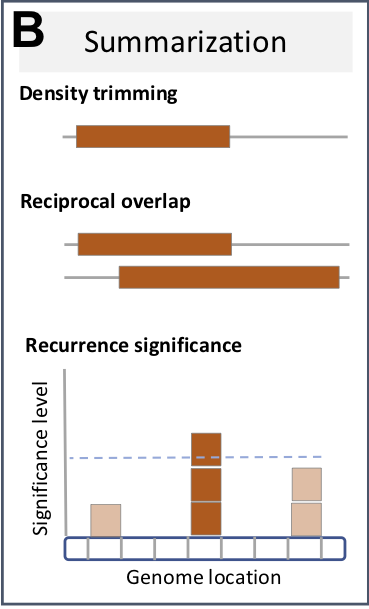

In CNV analysis, it is often of interest to summarize individual calls across the population, (i.e. to define CNV regions), for subsequent association analysis with expression and phenotype data. In the simplest case, this just merges overlapping individual calls into summarized regions. However, this typically inflates CNV region size, and more appropriate approaches have been developed for this purpose.

As mentioned in the Introduction, we emphasize the need for quality control of CNV calls and appropriate accounting for sources of technical bias before applying these summarization functions (or in general downstream analysis with CNVRanger).

For instance, protocols for read-depth CNV calling typically exclude calls overlapping defined repetitive and low-complexity regions including the UCSC list of segmental duplications [Trost et al., 2018](https://doi.org/10.1016/j.ajhg.2017.12.007), [Zhou et al., 2018](https://doi.org/10.1136/jmedgenet-2018-105272). We also note that [CNVnator](https://doi.org/10.1101/gr.114876.110), a very popular read-depth CNV caller, implements the $q0$-filter to explicitely flag and, if desired, exclude calls that are likely to stem from such regions.  
If systematically over-represented in the input CNV calls, summarization procedures such as GISTIC will identify these regions as recurrent independent of whether there are biological or technical reasons for that.

## 5.1 Trimming low-density areas

Here, we use the approach from CNVRuler to summarize CNV calls to CNV regions (see [Figure 1](https://academic.oup.com/view-large/figure/83392426/bts239f1.jpeg) in [Kim et al., 2012](https://doi.org/10.1093/bioinformatics/bts239) for an illustration of the approach). This trims low-density areas as defined by the `density` argument, which is set here to <10% of the number of calls within a summarized region.

```r
cnvrs <- populationRanges(grl, density=0.1)
cnvrs
```

```
## GRanges object with 303 ranges and 2 metadata columns:
##         seqnames              ranges strand |      freq        type
##            <Rle>           <IRanges>  <Rle> | <numeric> <character>
##     [1]     chr1        16947-111645      * |       103        gain
##     [2]     chr1     1419261-1630187      * |        18        gain
##     [3]     chr1     1896112-2004603      * |       218        gain
##     [4]     chr1     4139727-4203274      * |         1        gain
##     [5]     chr1     4554832-4577608      * |        23        gain
##     ...      ...                 ...    ... .       ...         ...
##   [299]     chr2 136310067-136322489      * |         2        loss
##   [300]     chr2 136375337-136386940      * |         1        loss
##   [301]     chr2 136455546-136466040      * |         1        loss
##   [302]     chr2 136749793-136802493      * |        39        both
##   [303]     chr2 139194749-139665914      * |        58        both
##   -------
##   seqinfo: 2 sequences from an unspecified genome; no seqlengths
```

Note that CNV frequency (number of samples overlapping each region) and CNV type (gain, loss, or both) have also been annotated in the columns `freq` and `type`, respectively.

## 5.2 Reciprocal overlap

We also provide an implementation of the *Reciprocal Overlap (RO)* procedure that requires calls to sufficiently overlap with one another as e.g. used by [Conrad et al., 2010](https://doi.org/10.1038/nature08516). This merges calls with an RO above a threshold as given by the `ro.thresh` argument. For example, an RO of 0.51 between two genomic regions *A* and *B* requires that *B* overlaps at least 51% of *A*, *and* that *A* also overlaps at least 51% of *B*.

```r
ro.cnvrs <- populationRanges(grl[1:100], mode="RO", ro.thresh=0.51)
ro.cnvrs
```

```
## GRanges object with 85 ranges and 2 metadata columns:
##        seqnames              ranges strand |      freq        type
##           <Rle>           <IRanges>  <Rle> | <numeric> <character>
##    [1]     chr1         16947-45013      * |         6        gain
##    [2]     chr1         36337-67130      * |         6        gain
##    [3]     chr1        36337-105963      * |         6        gain
##    [4]     chr1     1419261-1506862      * |         3        gain
##    [5]     chr1     1539361-1625471      * |         3        gain
##    ...      ...                 ...    ... .       ...         ...
##   [81]     chr2 136215094-136232653      * |         2        loss
##   [82]     chr2 136749793-136776410      * |         1        gain
##   [83]     chr2 138738929-139004086      * |         1        loss
##   [84]     chr2 139194749-139274355      * |         1        gain
##   [85]     chr2 139324752-139665914      * |         3        loss
##   -------
##   seqinfo: 2 sequences from an unspecified genome; no seqlengths
```

## 5.3 Identifying recurrent regions

In particular in cancer, it is important to distinguish driver from passenger mutations, i.e. to distinguish meaningful events from random background aberrations. The [GISTIC](http://www.broadinstitute.org/cancer/cga/gistic) method identifies those regions of the genome that are aberrant more often than would be expected by chance, with greater weight given to high amplitude events (high-level copy-number gains or homozygous deletions) that are less likely to represent random aberrations ([Beroukhim et al., 2007](https://doi.org/10.1073/pnas.0710052104)).

By setting `est.recur=TRUE`, we deploy a `GISTIC`-like significance estimation

```r
cnvrs <- populationRanges(grl, density=0.1, est.recur=TRUE)
cnvrs
```

```
## GRanges object with 303 ranges and 3 metadata columns:
##         seqnames              ranges strand |      freq        type
##            <Rle>           <IRanges>  <Rle> | <numeric> <character>
##     [1]     chr1        16947-111645      * |       103        gain
##     [2]     chr1     1419261-1630187      * |        18        gain
##     [3]     chr1     1896112-2004603      * |       218        gain
##     [4]     chr1     4139727-4203274      * |         1        gain
##     [5]     chr1     4554832-4577608      * |        23        gain
##     ...      ...                 ...    ... .       ...         ...
##   [299]     chr2 136310067-136322489      * |         2        loss
##   [300]     chr2 136375337-136386940      * |         1        loss
##   [301]     chr2 136455546-136466040      * |         1        loss
##   [302]     chr2 136749793-136802493      * |        39        both
##   [303]     chr2 139194749-139665914      * |        58        both
##                      pvalue
##                   <numeric>
##     [1] 0.00980392156862742
##     [2]   0.107843137254902
##     [3]                   0
##     [4]   0.558823529411765
##     [5]  0.0882352941176471
##     ...                 ...
##   [299]   0.236111111111111
##   [300]   0.421296296296296
##   [301]   0.421296296296296
##   [302]  0.0588235294117647
##   [303]  0.0392156862745098
##   -------
##   seqinfo: 2 sequences from an unspecified genome; no seqlengths
```

and filter for recurrent CNVs that exceed a significance threshold of 0.05.

```r
subset(cnvrs, pvalue < 0.05)
```

```
## GRanges object with 17 ranges and 3 metadata columns:
##        seqnames              ranges strand |      freq        type
##           <Rle>           <IRanges>  <Rle> | <numeric> <character>
##    [1]     chr1        16947-111645      * |       103        gain
##    [2]     chr1     1896112-2004603      * |       218        gain
##    [3]     chr1   15984544-15996851      * |       116        loss
##    [4]     chr1   31686841-31695808      * |       274        loss
##    [5]     chr1   69205418-69219486      * |        46        loss
##    ...      ...                 ...    ... .       ...         ...
##   [13]     chr2   97882695-97896935      * |        80        loss
##   [14]     chr2 124330343-124398570      * |        39        loss
##   [15]     chr2 135096060-135271140      * |        84        gain
##   [16]     chr2 135290754-135553033      * |        83        gain
##   [17]     chr2 139194749-139665914      * |        58        both
##                     pvalue
##                  <numeric>
##    [1] 0.00980392156862742
##    [2]                   0
##    [3]  0.0185185185185185
##    [4] 0.00462962962962965
##    [5]  0.0416666666666666
##    ...                 ...
##   [13]  0.0231481481481481
##   [14]  0.0462962962962963
##   [15]  0.0196078431372549
##   [16]  0.0294117647058824
##   [17]  0.0392156862745098
##   -------
##   seqinfo: 2 sequences from an unspecified genome; no seqlengths
```

We can illustrate the landscape of recurrent CNV regions on chromosome 1 using `plotRecurrentRegions`.

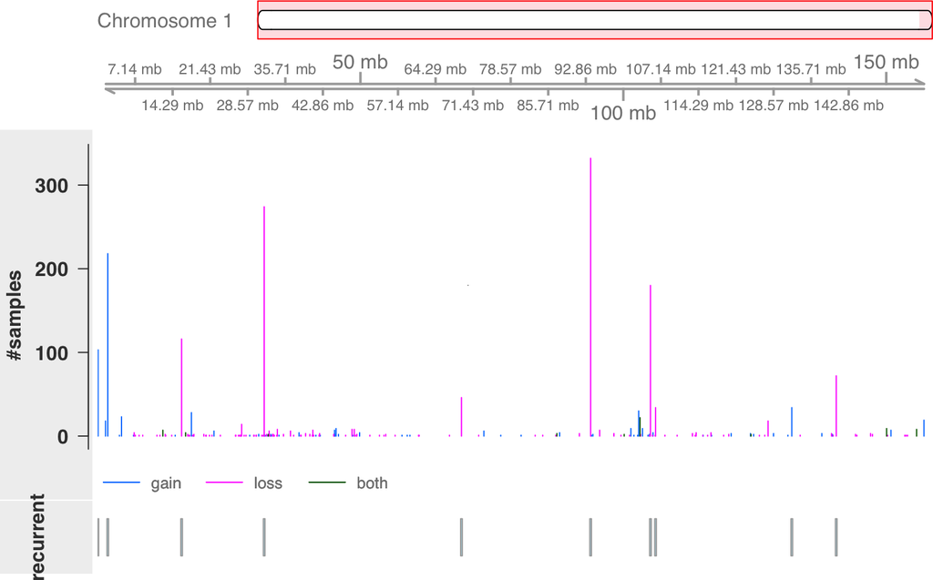

```r
plotRecurrentRegions(cnvrs, genome="bosTau6", chr="chr1")
```

# 6 Overlap analysis of CNVs with functional genomic regions

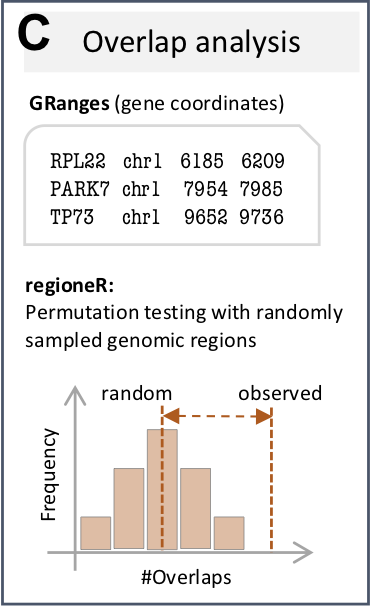

Once individual CNV calls have been summarized across the population, it is typically of interest whether the resulting CNV regions overlap with functional genomic regions such as genes, promoters, or enhancers. As a certain amount of overlap can be expected just by chance, an assessment of statistical significance is needed to decide whether the observed overlap is greater (enrichment) or less (depletion) than expected by chance.

The *regioneR* package implements a general framework for testing overlaps of genomic regions based on permutation sampling. This allows to repeatedly sample random regions from the genome, matching size and chromosomal distribution of the region set under study (here: the CNV regions). By recomputing the overlap with the functional features in each permutation, statistical significance of the observed overlap can be assessed.

We demonstrate in the following how this strategy can be used to assess the overlap between the detected CNV regions and protein-coding regions in the cattle genome. We expect to find a depletion as protein-coding regions are highly conserved and rarely subject to long-range structural variation such as CNV. Hence, is the overlap between CNVs and protein-coding genes less than expected by chance?

To obtain the location of protein-coding genes, we query available *Bos taurus* annotation from Ensembl

```r
library(AnnotationHub)
ah <- AnnotationHub::AnnotationHub()
```

```
## snapshotDate(): 2019-07-10
```

```r
ahDb <- AnnotationHub::query(ah, pattern = c("Bos taurus", "EnsDb"))
ahDb
```

```
## AnnotationHub with 11 records
## # snapshotDate(): 2019-07-10
## # $dataprovider: Ensembl
## # $species: Bos taurus
## # $rdataclass: EnsDb
## # additional mcols(): taxonomyid, genome, description,
## #   coordinate_1_based, maintainer, rdatadateadded, preparerclass,
## #   tags, rdatapath, sourceurl, sourcetype
## # retrieve records with, e.g., 'object[["AH53189"]]'
##
##             title
##   AH53189 | Ensembl 87 EnsDb for Bos Taurus
##   AH53693 | Ensembl 88 EnsDb for Bos Taurus
##   AH56658 | Ensembl 89 EnsDb for Bos Taurus
##   AH57731 | Ensembl 90 EnsDb for Bos Taurus
##   AH60745 | Ensembl 91 EnsDb for Bos Taurus
##   ...       ...
##   AH64416 | Ensembl 93 EnsDb for Bos Taurus
##   AH64886 | Ensembl 94 EnsDb for Bos taurus
##   AH67912 | Ensembl 95 EnsDb for Bos taurus
##   AH69141 | Ensembl 96 EnsDb for Bos taurus
##   AH73832 | Ensembl 97 EnsDb for Bos taurus
```

and retrieve gene coordinates in the UMD3.1 assembly (Ensembl 92).

```r
ahEdb <- ahDb[["AH60948"]]
```

```
## downloading 0 resources
```

```
## loading from cache
##     'AH60948 : 67694'
```

```
## require("ensembldb")
```

```r
bt.genes <- ensembldb::genes(ahEdb)
GenomeInfoDb::seqlevelsStyle(bt.genes) <- "UCSC"
bt.genes
```

```
## GRanges object with 24616 ranges and 8 metadata columns:
##                      seqnames              ranges strand |
##                         <Rle>           <IRanges>  <Rle> |
##   ENSBTAG00000046619     chr1         19774-19899      - |
##   ENSBTAG00000006858     chr1         34627-35558      + |
##   ENSBTAG00000039257     chr1         69695-71121      - |
##   ENSBTAG00000035349     chr1         83323-84281      - |
##   ENSBTAG00000001753     chr1       124849-179713      - |
##                  ...      ...                 ...    ... .
##   ENSBTAG00000025951     chrX 148526584-148535857      + |
##   ENSBTAG00000029592     chrX 148538917-148539037      - |
##   ENSBTAG00000016989     chrX 148576705-148582356      - |
##   ENSBTAG00000025952     chrX 148774930-148780901      - |
##   ENSBTAG00000047839     chrX 148804071-148805135      + |
##                                 gene_id   gene_name   gene_biotype
##                             <character> <character>    <character>
##   ENSBTAG00000046619 ENSBTAG00000046619     RF00001           rRNA
##   ENSBTAG00000006858 ENSBTAG00000006858                 pseudogene
##   ENSBTAG00000039257 ENSBTAG00000039257             protein_coding
##   ENSBTAG00000035349 ENSBTAG00000035349                 pseudogene
##   ENSBTAG00000001753 ENSBTAG00000001753             protein_coding
##                  ...                ...         ...            ...
##   ENSBTAG00000025951 ENSBTAG00000025951             protein_coding
##   ENSBTAG00000029592 ENSBTAG00000029592     RF00001           rRNA
##   ENSBTAG00000016989 ENSBTAG00000016989             protein_coding
##   ENSBTAG00000025952 ENSBTAG00000025952             protein_coding
##   ENSBTAG00000047839 ENSBTAG00000047839       P2RY8 protein_coding
##                      seq_coord_system
##                           <character>
##   ENSBTAG00000046619       chromosome
##   ENSBTAG00000006858       chromosome
##   ENSBTAG00000039257       chromosome
##   ENSBTAG00000035349       chromosome
##   ENSBTAG00000001753       chromosome
##                  ...              ...
##   ENSBTAG00000025951       chromosome
##   ENSBTAG00000029592       chromosome
##   ENSBTAG00000016989       chromosome
##   ENSBTAG00000025952       chromosome
##   ENSBTAG00000047839       chromosome
```

[output cut: 13 more lines]

```
##                           gene_id_version      symbol  entrezid
##                               <character> <character>    <list>
##   ENSBTAG00000046619 ENSBTAG00000046619.1     RF00001        NA
##   ENSBTAG00000006858 ENSBTAG00000006858.5                    NA
##   ENSBTAG00000039257 ENSBTAG00000039257.2                    NA
##   ENSBTAG00000035349 ENSBTAG00000035349.3                    NA
##   ENSBTAG00000001753 ENSBTAG00000001753.4                507243
##                  ...                  ...         ...       ...
##   ENSBTAG00000025951 ENSBTAG00000025951.4                    NA
##   ENSBTAG00000029592 ENSBTAG00000029592.1     RF00001        NA
##   ENSBTAG00000016989 ENSBTAG00000016989.5                    NA
##   ENSBTAG00000025952 ENSBTAG00000025952.3                785083
##   ENSBTAG00000047839 ENSBTAG00000047839.1       P2RY8 100299937
##   -------
##   seqinfo: 48 sequences from UMD3.1 genome
```

To speed up the example, we restrict analysis to chromosomes 1 and 2.

```r
sel.genes <- subset(bt.genes, seqnames %in% paste0("chr", 1:2))
sel.genes <- subset(sel.genes, gene_biotype == "protein_coding")
sel.cnvrs <- subset(cnvrs, seqnames %in% paste0("chr", 1:2))
```

Now, we are applying an overlap permutation test with 100 permutations (`ntimes=100`), while maintaining chromosomal distribution of the CNV region set (`per.chromosome=TRUE`). Furthermore, we use the option `count.once=TRUE` to count an overlapping CNV region only once, even if it overlaps with 2 or more genes. We also allow random regions to be sampled from the entire genome (`mask=NA`), although in certain scenarios masking certain regions such as telomeres and centromeres is advisable. Also note that we use 100 permutations for demonstration only. To draw robust conclusions a minimum of 1000 permutations should be carried out.

```r
library(regioneR)
library(BSgenome.Btaurus.UCSC.bosTau6.masked)
res <- regioneR::overlapPermTest(A=sel.cnvrs, B=sel.genes, ntimes=100,
    genome="bosTau6", mask=NA, per.chromosome=TRUE, count.once=TRUE)
res
```

```
## $numOverlaps
## P-value: 0.0198019801980198
## Z-score: -2.2527
## Number of iterations: 100
## Alternative: less
## Evaluation of the original region set: 97
## Evaluation function: numOverlaps
## Randomization function: randomizeRegions
##
## attr(,"class")
## [1] "permTestResultsList"
```

```r
summary(res[[1]]$permuted)
```

```
##    Min. 1st Qu.  Median    Mean 3rd Qu.    Max.
##    97.0   110.0   116.0   115.9   121.2   137.0
```

The resulting permutation *p*-value indicates a significant depletion. Out of the 303 CNV regions, 97 overlap with at least one gene. In contrast, when repeatedly drawing random regions matching the CNV regions in size and chromosomal distribution, the mean number of overlapping regions across permutations was 115.9 $\pm$ 8.4.

This finding is consistent with our observations across the whole genome ([da Silva et al., 2016](https://doi.org/10.1371/journal.pone.0157711)) and findings from the 1000 Genomes Poject ([Sudmant et al., 2015](https://www.nature.com/articles/nature15394)).

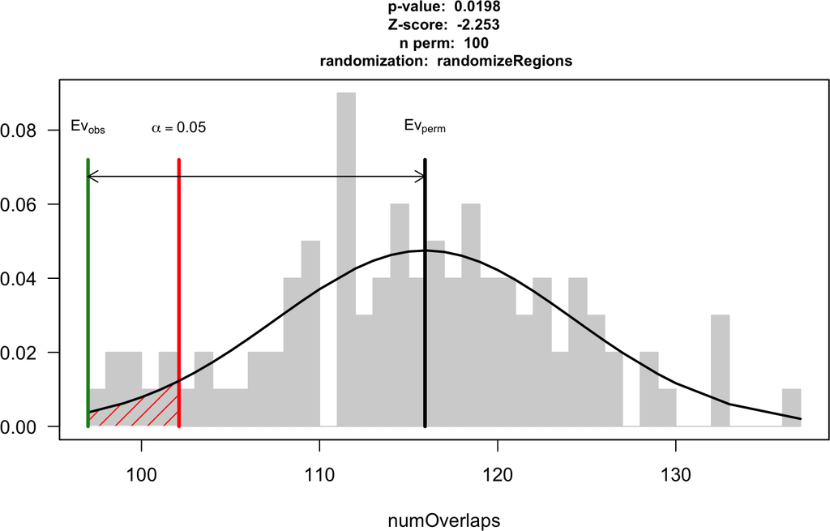

```r
plot(res)
```

Note: the function `regioneR::permTest` allows to incorporate user-defined functions for randomizing regions and evaluating additional measures of overlap such as total genomic size in bp.

# 7 CNV-expression association analysis

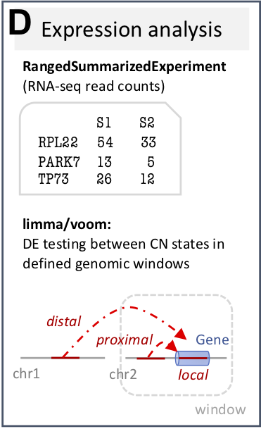

Studies of expression quantitative trait loci (eQTLs) aim at the discovery of genetic variants that explain variation in gene expression levels ([Nica and Dermitzakis, 2013](https://www.ncbi.nlm.nih.gov/pubmed/23650636)). Mainly applied in the context of SNPs, the concept also naturally extends to the analysis of CNVs.

The *CNVRanger* package implements association testing between CNV regions and RNA-seq read counts using *edgeR*, which applies generalized linear models based on the negative-binomial distribution while incorporating normalization factors for different library sizes.

In the case of only one CN state deviating from 2n for a CNV region under investigation, this reduces to the classical 2-group comparison. For more than two states (e.g. 0n, 1n, 2n), edgeR’s ANOVA-like test is applied to test all deviating groups for significant expression differences relative to 2n.

## 7.1 Dealing with individual CNV and RNA-seq assays

We demonstrate the functionality by loading RNA-seq read count data from skeletal muscle samples for 183 Nelore cattle steers, which we analyzed for CNV-expression effects as previously described ([Geistlinger et al., 2018](https://doi.org/10.1038/s41598-018-19782-4)).

```r
rseq.file <- file.path(data.dir, "counts_cleaned.txt")
rcounts <- read.delim(rseq.file, row.names=1, stringsAsFactors=FALSE)
rcounts <- as.matrix(rcounts)
dim(rcounts)
```

```
## [1] 939 183
```

```r
rcounts[1:5, 1:5]
```

```
##                    NE001407 NE001408 NE001424 NE001439 NE001448
## ENSBTAG00000000088       64       65      233      135      134
## ENSBTAG00000000160       20       28       50       13       18
## ENSBTAG00000000176      279      373      679      223      417
## ENSBTAG00000000201      252      271      544      155      334
## ENSBTAG00000000210      268      379      486      172      443
```

For demonstration, we restrict analysis to the 939 genes on chromosome 1 and 2, and store the RNA-seq expression data in a *SummarizedExperiment*.

```r
library(SummarizedExperiment)
rranges <- GenomicRanges::granges(sel.genes)[rownames(rcounts)]
rse <- SummarizedExperiment(assays=list(rcounts=rcounts), rowRanges=rranges)
rse
```

```
## class: RangedSummarizedExperiment
## dim: 939 183
## metadata(0):
## assays(1): rcounts
## rownames(939): ENSBTAG00000000088 ENSBTAG00000000160 ...
##   ENSBTAG00000048210 ENSBTAG00000048228
## rowData names(0):
## colnames(183): NE001407 NE001408 ... NE003840 NE003843
## colData names(0):
```

Assuming distinct modes of action, effects observed in the CNV-expression analysis are typically divided into (i) local effects (*cis*), where expression changes coincide with CNVs in the respective genes, and (ii) distal effects (*trans*), where CNVs supposedly affect trans-acting regulators such as transcription factors.

However, due to power considerations and to avoid detection of spurious effects, stringent filtering of (i) not sufficiently expressed genes, and (ii) CNV regions with insufficient sample size in groups deviating from 2n, should be carried out when testing for distal effects. Local effects have a clear spatial indication and the number of genes locating in or close to a CNV region of interest is typically small; testing for differential expression between CN states is thus generally better powered for local effects and less stringent filter criteria can be applied.

In the following, we carry out CNV-expression association analysis by providing the CNV regions to test (`cnvrs`), the individual CNV calls (`grl`) to determine per-sample CN state in each CNV region, the RNA-seq read counts (`rse`), and the size of the genomic window around each CNV region (`window`). The `window` argument thereby determines which genes are considered for testing for each CNV region and is set here to 1 Mbp.

Further, use the `min.cpm` and `min.samples` arguments to exclude from the analysis (i) genes with fewer than `min.cpm` reads per million reads mapped (cpm, counts per million), and (ii) CNV regions with fewer than `min.samples` samples in a group deviating from 2n.

```r
res <- cnvEQTL(cnvrs, grl, rse, window="1Mbp", verbose=TRUE)
```

```
## Restricting analysis to 179 intersecting samples
```

```
## Preprocessing RNA-seq data ...
```

```
## Summarizing per-sample CN state in each CNV region
```

```
## Excluding 286 cnvrs not satisfying min.samples threshold
```

```
## Analyzing 12 regions with >=1 gene in the given window
```

```
## 1 of 12
```

```
## 2 of 12
```

```
## 3 of 12
```

```
## 4 of 12
```

```
## 5 of 12
```

```
## 6 of 12
```

```
## 7 of 12
```

```
## 8 of 12
```

```
## 9 of 12
```

```
## 10 of 12
```

```
## 11 of 12
```

```
## 12 of 12
```

```r
res
```

```
## GRangesList object of length 12:
## $`chr1:16947-111645`
## GRanges object with 5 ranges and 5 metadata columns:
##                                        seqnames         ranges strand |
##                                           <Rle>      <IRanges>  <Rle> |
##   chr1:16947-111645.ENSBTAG00000018278     chr1  922635-929992      + |
##   chr1:16947-111645.ENSBTAG00000021997     chr1 944294-1188287      - |
##   chr1:16947-111645.ENSBTAG00000020035     chr1  351708-362907      + |
##   chr1:16947-111645.ENSBTAG00000011528     chr1  463572-478996      - |
##   chr1:16947-111645.ENSBTAG00000012594     chr1  669920-733729      - |
##                                        logFC.CN0 logFC.CN1
##                                        <numeric> <numeric>
##   chr1:16947-111645.ENSBTAG00000018278      <NA>      <NA>
##   chr1:16947-111645.ENSBTAG00000021997      <NA>      <NA>
##   chr1:16947-111645.ENSBTAG00000020035      <NA>      <NA>
##   chr1:16947-111645.ENSBTAG00000011528      <NA>      <NA>
##   chr1:16947-111645.ENSBTAG00000012594      <NA>      <NA>
##                                                   logFC.CN3
##                                                   <numeric>
##   chr1:16947-111645.ENSBTAG00000018278    0.194859708204693
##   chr1:16947-111645.ENSBTAG00000021997  -0.0812496004002579
##   chr1:16947-111645.ENSBTAG00000020035   0.0745028563584966
##   chr1:16947-111645.ENSBTAG00000011528   0.0118392582964246
##   chr1:16947-111645.ENSBTAG00000012594 -0.00661188778069866
##                                                     PValue         AdjPValue
##                                                  <numeric>         <numeric>
##   chr1:16947-111645.ENSBTAG00000018278 0.00731514635942643 0.400665393143051
##   chr1:16947-111645.ENSBTAG00000021997   0.179616021014231  0.84156465759891
##   chr1:16947-111645.ENSBTAG00000020035   0.740325113668157 0.997718543341936
##   chr1:16947-111645.ENSBTAG00000011528   0.915565410368907 0.997718543341936
##   chr1:16947-111645.ENSBTAG00000012594   0.943057146391631 0.997718543341936
##   -------
##   seqinfo: 48 sequences from UMD3.1 genome
##
## ...
## <11 more elements>
```

## 7.2 Dealing with TCGA data stored in a `MultiAssayExperiment`

In the previous section, we individually prepared the CNV and RNA-seq data for CNV-expression association analysis. In the following, we demonstrate how to perform an integrated preparation of the two assays when stored in a *MultiAssayExperiment*. We therefore consider glioblastoma [GBM](https://cancergenome.nih.gov/cancersselected/glioblastomamultiforme) data from The Cancer Genome Atlas [TCGA](https://cancergenome.nih.gov), which can conveniently be accessed with the *curatedTCGAData* package.

```r
library(curatedTCGAData)
gbm <- curatedTCGAData::curatedTCGAData("GBM",
        assays=c("GISTIC_Peaks", "CNVSNP", "RNASeq2GeneNorm"),
        dry.run=FALSE)
```

```r
gbm
```

```
## A MultiAssayExperiment object of 3 listed
##  experiments with user-defined names and respective classes.
##  Containing an ExperimentList class object of length 3:
##  [1] GBM_CNVSNP-20160128: RaggedExperiment with 146852 rows and 1104 columns
##  [2] GBM_RNASeq2GeneNorm-20160128: SummarizedExperiment with 20501 rows and 166 columns
##  [3] GBM_GISTIC_Peaks-20160128: RangedSummarizedExperiment with 68 rows and 577 columns
## Features:
##  experiments() - obtain the ExperimentList instance
##  colData() - the primary/phenotype DataFrame
##  sampleMap() - the sample availability DataFrame
##  `$`, `[`, `[[` - extract colData columns, subset, or experiment
##  *Format() - convert into a long or wide DataFrame
##  assays() - convert ExperimentList to a SimpleList of matrices
```

The returned `MultiAssayExperiment` contains three assays:

- the SNP-based CNV calls stored in a `RaggedExperiment` (`GBM_CNVSNP`),
- the recurrent CNV regions summarized across the population using the [GISTIC](http://www.broadinstitute.org/cancer/cga/gistic) method (`GBM_GISTIC_Peaks`), and
- the normalized RNA-seq gene expression values in a `SummarizedExperiment` (`GBM_RNASeq2GeneNorm`).

To annotate the genomic coordinates of the genes measured in the RNA-seq assay, we use the function `symbolsToRanges` from the *TCGAutils* package. For demonstration, we restrict the analysis to chromosome 1 and 2.

```r
library(TCGAutils)
gbm <- TCGAutils::symbolsToRanges(gbm, unmapped=FALSE)
for(i in 1:3)
{
    rr <- rowRanges(gbm[[i]])
    GenomeInfoDb::genome(rr) <- "hg19"
    GenomeInfoDb::seqlevelsStyle(rr) <- "UCSC"
    ind <- as.character(seqnames(rr)) %in% c("chr1", "chr2")
    rowRanges(gbm[[i]]) <- rr
    gbm[[i]] <- gbm[[i]][ind,]
}
gbm
```

```
## A MultiAssayExperiment object of 3 listed
##  experiments with user-defined names and respective classes.
##  Containing an ExperimentList class object of length 3:
##  [1] GBM_CNVSNP-20160128: RaggedExperiment with 17818 rows and 1104 columns
##  [2] GBM_GISTIC_Peaks-20160128: RangedSummarizedExperiment with 12 rows and 577 columns
##  [3] GBM_RNASeq2GeneNorm-20160128_ranged: RangedSummarizedExperiment with 2939 rows and 166 columns
## Features:
##  experiments() - obtain the ExperimentList instance
##  colData() - the primary/phenotype DataFrame
##  sampleMap() - the sample availability DataFrame
##  `$`, `[`, `[[` - extract colData columns, subset, or experiment
##  *Format() - convert into a long or wide DataFrame
##  assays() - convert ExperimentList to a SimpleList of matrices
```

We now restrict the analysis to intersecting patients of the three assays using `MultiAssayExperiment`’s `intersectColumns` function, and select *Primary Solid Tumor* samples using the `splitAssays` function from the *TCGAutils* package.

```r
gbm <- MultiAssayExperiment::intersectColumns(gbm)
TCGAutils::sampleTables(gbm)
```

```
## $`GBM_CNVSNP-20160128`
##
##  01  02  10  11
## 154  13 146   1
##
## $`GBM_GISTIC_Peaks-20160128`
##
##  01
## 154
##
## $`GBM_RNASeq2GeneNorm-20160128_ranged`
##
##  01  02
## 147  13
```

```r
data(sampleTypes, package="TCGAutils")
sampleTypes
```

```
##    Code                                        Definition Short.Letter.Code
## 1    01                               Primary Solid Tumor                TP
## 2    02                             Recurrent Solid Tumor                TR
## 3    03   Primary Blood Derived Cancer - Peripheral Blood                TB
## 4    04      Recurrent Blood Derived Cancer - Bone Marrow              TRBM
## 5    05                          Additional - New Primary               TAP
## 6    06                                        Metastatic                TM
## 7    07                             Additional Metastatic               TAM
## 8    08                        Human Tumor Original Cells              THOC
## 9    09        Primary Blood Derived Cancer - Bone Marrow               TBM
## 10   10                              Blood Derived Normal                NB
## 11   11                               Solid Tissue Normal                NT
## 12   12                                Buccal Cell Normal               NBC
## 13   13                           EBV Immortalized Normal              NEBV
## 14   14                                Bone Marrow Normal               NBM
## 15   15                                    sample type 15              15SH
## 16   16                                    sample type 16              16SH
## 17   20                                   Control Analyte             CELLC
## 18   40 Recurrent Blood Derived Cancer - Peripheral Blood               TRB
## 19   50                                        Cell Lines              CELL
## 20   60                          Primary Xenograft Tissue                XP
## 21   61                Cell Line Derived Xenograft Tissue               XCL
## 22   99                                    sample type 99              99SH
```

```r
gbm <- TCGAutils::splitAssays(gbm, sampleCodes="01")
gbm
```

```
## A MultiAssayExperiment object of 3 listed
##  experiments with user-defined names and respective classes.
##  Containing an ExperimentList class object of length 3:
##  [1] 01_GBM_CNVSNP-20160128: RaggedExperiment with 17818 rows and 154 columns
##  [2] 01_GBM_GISTIC_Peaks-20160128: RangedSummarizedExperiment with 12 rows and 154 columns
##  [3] 01_GBM_RNASeq2GeneNorm-20160128_ranged: RangedSummarizedExperiment with 2939 rows and 147 columns
## Features:
##  experiments() - obtain the ExperimentList instance
##  colData() - the primary/phenotype DataFrame
##  sampleMap() - the sample availability DataFrame
##  `$`, `[`, `[[` - extract colData columns, subset, or experiment
##  *Format() - convert into a long or wide DataFrame
##  assays() - convert ExperimentList to a SimpleList of matrices
```

We transform CN estimates into CN states where states are encoded as:

- `0`: homozygous deletion (2-copy loss)
- `1`: heterozygous deletion (1-copy loss)
- `2`: normal diploid state
- `3`: 1-copy gain
- `4`: amplification (>= 2-copy gain)

```r
ind <- grep("CNVSNP", names(gbm))
smean <- mcols(gbm[[ind]])$Segment_Mean
state <- round(2^smean * 2)
state[state > 4] <- 4
mcols(gbm[[ind]])$State <- state
mcols(gbm[[ind]]) <- mcols(gbm[[ind]])[,3:1]
table(mcols(gbm[[ind]])$State)
```

```
##
##    0    1    2    3    4
## 2401 4084 9581 1005  747
```

The data is now ready for CNV-expression association analysis, where we find only four CNV regions with sufficient sample size for testing using the default value of 10 for the `minSamples` argument.

```r
res <- cnvEQTL(cnvrs="01_GBM_GISTIC_Peaks-20160128",
    calls="01_GBM_CNVSNP-20160128",
    rcounts="01_GBM_RNASeq2GeneNorm-20160128_ranged",
    data=gbm, window="1Mbp", verbose=TRUE)
```

```
## harmonizing input:
##   removing 154 sampleMap rows not in names(experiments)
```

```
## Preprocessing RNA-seq data ...
```

```
## Summarizing per-sample CN state in each CNV region
```

```
## Excluding 8 cnvrs not satisfying min.samples threshold
```

```
## Analyzing 4 regions with >=1 gene in the given window
```

```
## 1 of 4
```

```
## 2 of 4
```

```
## 3 of 4
```

```
## 4 of 4
```

```r
res
```

```
## GRangesList object of length 4:
## $`chr1:3394251-6475685`
## GRanges object with 29 ranges and 5 metadata columns:
##                                 seqnames          ranges strand |
##                                    <Rle>       <IRanges>  <Rle> |
##      chr1:3394251-6475685.RPL22     chr1 6245080-6259679      - |
##     chr1:3394251-6475685.CAMTA1     chr1 6845384-7829766      + |
##     chr1:3394251-6475685.KLHL21     chr1 6650779-6662929      - |
##    chr1:3394251-6475685.DNAJC11     chr1 6694228-6761966      - |
##      chr1:3394251-6475685.PHF13     chr1 6673756-6684093      + |
##                             ...      ...             ...    ... .
##       chr1:3394251-6475685.CHD5     chr1 6161847-6240194      - |
##     chr1:3394251-6475685.PRDM16     chr1 2985742-3355185      + |
##       chr1:3394251-6475685.HES5     chr1 2460184-2461684      - |
##   chr1:3394251-6475685.TNFRSF14     chr1 2487805-2495267      + |
##   chr1:3394251-6475685.TNFRSF25     chr1 6521214-6526255      - |
##                                          logFC.CN1 logFC.CN3 logFC.CN4
##                                          <numeric> <numeric> <numeric>
##      chr1:3394251-6475685.RPL22 -0.721168611202118      <NA>      <NA>
##     chr1:3394251-6475685.CAMTA1  -0.70045823909777      <NA>      <NA>
##     chr1:3394251-6475685.KLHL21 -0.789504789475756      <NA>      <NA>
##    chr1:3394251-6475685.DNAJC11 -0.636852847538795      <NA>      <NA>
##      chr1:3394251-6475685.PHF13 -0.615744216633161      <NA>      <NA>
##                             ...                ...       ...       ...
##       chr1:3394251-6475685.CHD5 -0.734544520067391      <NA>      <NA>
##     chr1:3394251-6475685.PRDM16 -0.328987990681955      <NA>      <NA>
##       chr1:3394251-6475685.HES5  0.380841126461591      <NA>      <NA>
##   chr1:3394251-6475685.TNFRSF14  0.150779753897248      <NA>      <NA>
##   chr1:3394251-6475685.TNFRSF25 -0.177540215512479      <NA>      <NA>
##                                               PValue            AdjPValue
##                                            <numeric>            <numeric>
##      chr1:3394251-6475685.RPL22 1.33805098555682e-08 5.27786777636303e-08
##     chr1:3394251-6475685.CAMTA1 3.11715100425925e-07 1.05389391096384e-06
##     chr1:3394251-6475685.KLHL21  5.8583843625014e-06 1.73310537390666e-05
##    chr1:3394251-6475685.DNAJC11 7.68837679200396e-06 2.18349900892913e-05
##      chr1:3394251-6475685.PHF13 1.07996745663133e-05 2.94914190080095e-05
##                             ...                  ...                  ...
##       chr1:3394251-6475685.CHD5    0.254308159934797     0.30093132258951
##     chr1:3394251-6475685.PRDM16    0.409873374590232    0.454703274936039
##       chr1:3394251-6475685.HES5     0.47829809903912    0.513197098742068
##   chr1:3394251-6475685.TNFRSF14    0.484284586136881    0.513197098742068
##   chr1:3394251-6475685.TNFRSF25    0.579484808513276    0.596281469629603
##   -------
##   seqinfo: 25 sequences (1 circular) from hg19 genome
##
## ...
## <3 more elements>
```

# 8 CNV-phenotype association analysis

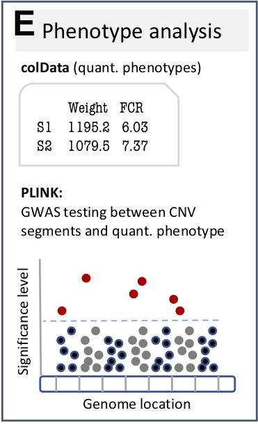

For CNV calls inferred from SNP-chip or sequencing data, we additionally provide functionality to carry out a probe-level genome-wide association study (GWAS) between CNVs and quantitative phenotypes as previously described ([da Silva et al., 2016](https://doi.org/10.1371/journal.pone.0157711)).

This treats common CN polymorphisms (CNPs, allele frequency >1%) as SNPs of equal frequency and carries out a GWAS as implemented in [PLINK](http://zzz.bwh.harvard.edu/plink/gvar.shtml). The current version of `cnvGWAS` fucntion runs the CNV-phenotype in the background with [PLINK](http://zzz.bwh.harvard.edu/plink/gvar.shtml), import the results and assign SNP probe *p*-values to their respective CNV segments.

For demonstration, we use CNV data of a wild population of songbirds ([da Silva et al., 2018](https://doi.org/10.1186/s12864-018-4577-1)).

As before we read in the CNV calls and store them in a `GRangesList`.

```r
cnv.loc <- file.path(data.dir, "CNVOut.txt")
cnv.calls <- read.delim(cnv.loc, as.is=TRUE)
cnv.calls <- GenomicRanges::makeGRangesListFromDataFrame(cnv.calls,
    split.field="sample.id", keep.extra.columns=TRUE)
cnv.calls
```

```
## GRangesList object of length 10:
## $`112`
## GRanges object with 2 ranges and 4 metadata columns:
##       seqnames              ranges strand |     state  num.snps  start.probe
##          <Rle>           <IRanges>  <Rle> | <integer> <integer>  <character>
##   [1]        1 100727703-100730748      * |         0         8 AX-100388724
##   [2]       10   19062731-19096193      * |         3         9 AX-100271359
##          end.probe
##        <character>
##   [1] AX-100765659
##   [2] AX-100147230
##   -------
##   seqinfo: 10 sequences from an unspecified genome; no seqlengths
##
## $`175`
## GRanges object with 2 ranges and 4 metadata columns:
##       seqnames          ranges strand |     state  num.snps  start.probe
##          <Rle>       <IRanges>  <Rle> | <integer> <integer>  <character>
##   [1]       27 2299391-2308228      * |         3         6 AX-100610990
##   [2]        8 4122253-4193189      * |         3        62 AX-100097083
##          end.probe
##        <character>
##   [1] AX-100178489
##   [2] AX-100912769
##   -------
##   seqinfo: 10 sequences from an unspecified genome; no seqlengths
##
## $`356`
## GRanges object with 1 range and 4 metadata columns:
##       seqnames              ranges strand |     state  num.snps  start.probe
##          <Rle>           <IRanges>  <Rle> | <integer> <integer>  <character>
##   [1]        1 100728444-100730748      * |         0         6 AX-100700982
##          end.probe
##        <character>
##   [1] AX-100765659
##   -------
##   seqinfo: 10 sequences from an unspecified genome; no seqlengths
##
## ...
## <7 more elements>
```

Here, we use genomic estimated breeding values (GEBVs) for breeding time (BT) as the quantitative phenotype, and accordingly analyze for each CNV region whether change in copy number is associated with change in the genetic potential for breeding time.

## 8.1 Setting up a CNV-GWAS

The function `setupCnvGWAS` imports CNV calls, phenotype information, and the probe map (if available). The information required for analysis is then stored in the resulting `phen.info` list:

```r
## GEBV values
phen.loc <- file.path(data.dir, "Pheno.txt")

## Genomic positions of the probes used in the CNV call
map.loc <- file.path(data.dir, "MapPenn.txt")

phen.info <- setupCnvGWAS("example", phen.loc, cnv.calls, map.loc)
```

```r
## Phenotypes and CNVs can be also be imported as a RaggedExperiment object
phen.df <- read.delim(phen.loc)
colDat <- S4Vectors::DataFrame(phen.df)
re <- RaggedExperiment::RaggedExperiment(cnv.calls, colData=colDat)
re
```

```
## class: RaggedExperiment
## dim: 19 10
## assays(4): state num.snps start.probe end.probe
## rownames: NULL
## colnames(10): 112 175 ... 1334 2391
## colData names(4): sample.id fam sex BT
```

```r
phen.info <- setupCnvGWAS("example", cnv.out.loc=re, map.loc=map.loc)
phen.info
```

```
## $samplesPhen
##  [1] "911"  "622"  "1195" "112"  "175"  "2391" "1068" "546"  "356"  "1334"
##
## $phenotypes
## [1] "BT"
##
## $phenotypesdf
##           BT
## 1  -2.842842
## 2  -2.884186
## 3  -3.062731
## 4  -3.161435
## 5  -3.597768
## 6   3.623262
## 7   3.216123
## 8   3.129881
## 9   3.106459
## 10  3.004740
##
## $phenotypesSam
##    samplesPhen        BT
## 1          911 -2.842842
## 2          622 -2.884186
## 3         1195 -3.062731
## 4          112 -3.161435
## 5          175 -3.597768
## 6         2391  3.623262
## 7         1068  3.216123
## 8          546  3.129881
## 9          356  3.106459
## 10        1334  3.004740
##
## $FamID
##    samplesPhen  V2
## 1          911  -9
## 2          622  -9
## 3         1195 622
## 4          112  -9
## 5          175  -9
## 6         2391  -9
```

[output cut: 10 more lines]

```
## 4          112  2
## 5          175  2
## 6         2391  2
## 7         1068  2
## 8          546  2
## 9          356  2
## 10        1334  2
##
## $all.paths
##                                                                                   Inputs
##                     "/Users/ludwig/Library/Application Support/CNVRanger/example/Inputs"
##                                                                                    PLINK
## "/Users/ludwig/Library/Application Support/CNVRanger/example/PLINK/plink-1.07-mac-intel"
##                                                                                  Results
##                    "/Users/ludwig/Library/Application Support/CNVRanger/example/Results"
```

The last item of the list displays the working directory:

```r
all.paths <- phen.info$all.paths
all.paths
```

```
##                                                                                   Inputs
##                     "/Users/ludwig/Library/Application Support/CNVRanger/example/Inputs"
##                                                                                    PLINK
## "/Users/ludwig/Library/Application Support/CNVRanger/example/PLINK/plink-1.07-mac-intel"
##                                                                                  Results
##                    "/Users/ludwig/Library/Application Support/CNVRanger/example/Results"
```

For the GWAS, chromosome names are assumed to be `integer` (i.e. `1, 2, 3, ...`). Non-integer chromosome names can be encoded by providing a `data.frame` that describes the mapping from `character` names to corresponding integers.

For the example data, chromosomes *1A*, *4A*, *25LG1*, *25LG2*, and *LGE22* are correspondingly encoded via

```r
# Define chr correspondence to numeric
chr.code.name <- data.frame(
                    V1 = c(16, 25, 29:31),
                    V2 = c("1A", "4A", "25LG1", "25LG2", "LGE22"))
```

## 8.2 Running a CNV-GWAS

We can then run the actual CNV-GWAS, here without correction for multiple testing which is done *for demonstration only*. In real analyses, multiple testing correction is recommended to avoid inflation of false positive findings.

```r
segs.pvalue.gr <- cnvGWAS(phen.info, chr.code.name=chr.code.name, method.m.test="none")
segs.pvalue.gr
```

```
## GRanges object with 16 ranges and 6 metadata columns:
##        seqnames              ranges strand |   SegName MinPvalue
##           <Rle>           <IRanges>  <Rle> | <integer> <numeric>
##    [1]        1   98171563-98184039      * |         2    0.0323
##    [2]        8     4121283-4188293      * |         7   0.03494
##    [3]        8             4193189      * |         8    0.1124
##    [4]        1   98186123-98186543      * |         3    0.1202
##    [5]        1   98147555-98171009      * |         1    0.1977
##    ...      ...                 ...    ... .       ...       ...
##   [12]       18     1278467-1295371      * |        13    0.3856
##   [13]       11            18840662      * |        12    0.3926
##   [14]       21     3326720-3329134      * |        14    0.3926
##   [15]       11   18836038-18839377      * |        11    0.9688
##   [16]        1 100728444-100730326      * |         4    0.9722
##           NameProbe   Frequency MinPvalueAdjusted   Phenotype
##         <character> <character>         <numeric> <character>
##    [1] AX-100075281           3            0.0323          BT
##    [2] AX-100015058           3           0.03494          BT
##    [3] AX-100912769           2            0.1124          BT
##    [4] AX-100011247           2            0.1202          BT
##    [5] AX-100171012           4            0.1977          BT
##    ...          ...         ...               ...         ...
##   [12] AX-100116173           1            0.3856          BT
##   [13] AX-100673859           1            0.3926          BT
##   [14] AX-100389358           1            0.3926          BT
##   [15] AX-100337682           2            0.9688          BT
##   [16] AX-100108194           2            0.9722          BT
##   -------
##   seqinfo: 10 sequences from an unspecified genome; no seqlengths
```

The CNV-GWAS uses the concept of CNV segments to define CNV loci.

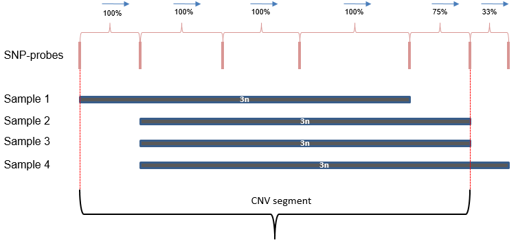

Figure 1: Definition of CNV segments

This procedure was originally proposed in our previous work in Nelore cattle ([da Silva et al., 2016](https://doi.org/10.1371/journal.pone.0157711)) and defines CNV segments based on CNV genotype similarity of subsequent SNP probes.

The default is `min.sim=0.95`, which will continuously add probe positions to a given CNV segment until the pairwise genotype similarity drops below 95%. An example of detailed up-down CNV genotype concordance that is used for the construction of CNV segments is given in S12 Table in [da Silva et al., 2016](https://doi.org/10.1371/journal.pone.0157711).

As `PLINK` returns a *p*-value for each probe, only one of the *p*-values of the probes contained in a CNV segment is chosen as the segment *p*-value.

This is similar to a common approach used in differential expression (DE) analysis of microarray gene expression data, where typically the most significant DE probe is chosen in case of multiple probes mapping to the same gene.

Here, the representative probe for the CNV segment can be chosen to be the probe with lowest *p*-value (`assign.probe="min.pvalue"`, default) or the one with highest CNV frequency (`assign.probe="high.freq"`).

Multiple testing correction based on the number of CNV segments tested is carried out using the FDR approach (default). Results can then be displayed as for regular GWAS via a Manhattan plot (which can optionally be exported to a pdf file).

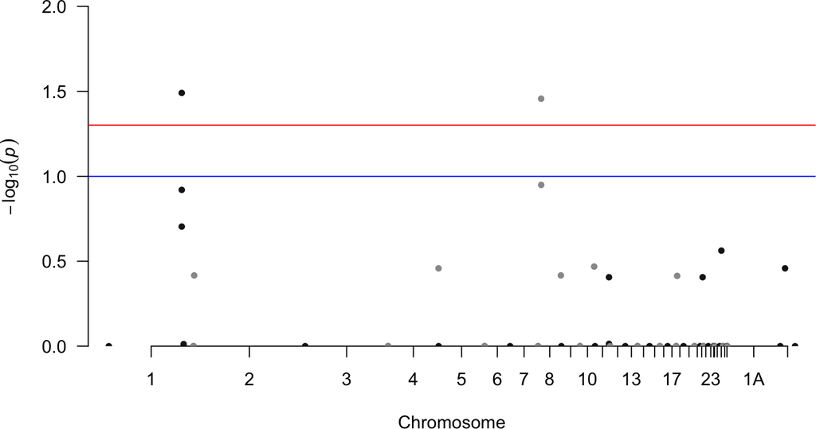

```r
## Define the chromosome order in the plot
order.chrs <- c(1:24, "25LG1", "25LG2", 27:28, "LGE22", "1A", "4A")

## Chromosome sizes
chr.size.file <- file.path(data.dir, "Parus_major_chr_sizes.txt")
chr.sizes <- scan(chr.size.file)
chr.size.order <- data.frame(chr=order.chrs, sizes=chr.sizes, stringsAsFactors=FALSE)

## Plot a pdf file with a manhatthan within the 'Results' workfolder
plotManhattan(all.paths, segs.pvalue.gr, chr.size.order, plot.pdf=FALSE)
```

## 8.3 Producing a GDS file in advance

To support an efficient memory management in genotype analysis, the genomic data structure (GDS) file format for array-oriented data was previously implemented in the *gdsfmt* package. Thus, to make use of this efficiency, CNV genotypes constructed and associated with the `cnvGWAS` function are stored in a `CNV.gds` file, which is automatically produced and placed in the `Inputs` folder (i.e. `all.paths[1]`).

Therefore, running a GWAS implies that any GDS file produced by previous analysis will be overwritten. Use `produce.gds=FALSE` to avoid overwriting in the GWAS run.

For convenience, a GDS file can be produced before the GWAS analysis with the `generateGDS` function. This additionally returns a `GRanges` object containing the genomic position, name and, frequency of each probe used to construct the CNV segments for the GWAS analysis.

Note that `probes.cnv.gr` object contains the integer chromosome names (as the GDS file on disk). Only the `segs.pvalue.gr`, which stores the GWAS results, has the character chromosome names.

```r
## Create a GDS file in disk and export the SNP probe positions
probes.cnv.gr <- generateGDS(phen.info, chr.code.name=chr.code.name)
probes.cnv.gr
```

```
## GRanges object with 189 ranges and 3 metadata columns:
##         seqnames    ranges strand |         Name      freq    snp.id
##            <Rle> <IRanges>  <Rle> |  <character> <integer> <integer>
##     [1]        1  98147555      * | AX-100939600         2         1
##     [2]        1  98148072      * | AX-100088448         2         2
##     [3]        1  98150537      * | AX-100954037         2         3
##     [4]        1  98151270      * | AX-100836117         2         4
##     [5]        1  98151959      * | AX-100027637         2         5
##     ...      ...       ...    ... .          ...       ...       ...
##   [185]       25   6471766      * | AX-100066308         1       185
##   [186]       25   6473449      * | AX-100023435         1       186
##   [187]       25   6474550      * | AX-100397956         1       187
##   [188]       25   6475943      * | AX-100363929         1       188
##   [189]       27   2308228      * | AX-100178489         1       189
##   -------
##   seqinfo: 15 sequences from an unspecified genome; no seqlengths
```

```r
## Run GWAS with existent GDS file
segs.pvalue.gr <- cnvGWAS(phen.info, chr.code.name=chr.code.name, produce.gds=FALSE)
```

## 8.4 Using relative signal intensities

CNV detection using SNP-chip intensities and allele frequencies can produce biased CNV frequencies ([da Silva et al., 2018](https://doi.org/10.1186/s12864-018-4577-1)). Therefore, we also provide the option to carry out the GWAS based on the SNP-wise relative signal intensities (log R ratios, LRRs), which reflect at certain extend the number of copies on the SNP region and are used as input for several CNV callers such as [PennCNV](http://penncnv.openbioinformatics.org) and [Birdsuit](https://www.broadinstitute.org/birdsuite/birdsuite). Directly using LRR values for the GWAS thereby facilitates the identification of CNV segments associated with the phenotype, disregarding putatively biased frequency estimates from a strict CNV calling procedure. Although sometimes interesting as an auxiliar analysis, using LRR values directly can generate false positive results as higher noise is expected in comparison with a CNV dataset detected and properly filtered by an external CNV caller software.

To perform the GWAS using LRR values, import the LRR/BAF values and set `run.lrr=TRUE` in the `cnvGWAS` function:

```r
# List files to import LRR/BAF
files <- list.files(data.dir, pattern = "\\.cnv.txt.adjusted$")
samples <- sub(".cnv.txt.adjusted$", "", files)
samples <- sub("^GT","", samples)
sample.files <- data.frame(file.names=files, sample.names=samples)

# All missing samples will have LRR = '0' and BAF = '0.5' in all SNPs listed in the GDS file
importLrrBaf(all.paths, data.dir, sample.files, verbose=FALSE)

# Read the GDS to check if the LRR/BAF nodes were added
cnv.gds <- file.path(all.paths[1], "CNV.gds")
(genofile <- SNPRelate::snpgdsOpen(cnv.gds, allow.fork=TRUE, readonly=FALSE))
```

```
## File: /Users/ludwig/Library/Application Support/CNVRanger/example/Inputs/CNV.gds (49.8K)
## +    [  ] *
## |--+ sample.id   { Str8 10 ZIP_ra(122.7%), 61B }
## |--+ snp.id   { Str8 189 ZIP_ra(45.4%), 301B }
## |--+ snp.rs.id   { Str8 189 ZIP_ra(31.9%), 791B }
## |--+ snp.position   { Int32 189 ZIP_ra(86.2%), 659B }
## |--+ snp.chromosome   { Str8 189 ZIP_ra(11.8%), 56B }
## |--+ genotype   { Bit2 189x10, 473B } *
## |--+ CNVgenotype   { Float64 189x10, 14.8K }
## |--+ phenotype   [ data.frame ] *
## |  |--+ samplesPhen   { Str8 10, 44B }
## |  \--+ BT   { Float64 10, 80B }
## |--+ FamID   { Str8 10, 31B }
## |--+ Sex   { Str8 10, 20B }
## |--+ Chr.names   [ data.frame ] *
## |  |--+ V1   { Float64 5, 40B }
## |  \--+ V2   { Int32,factor 5, 20B } *
## |--+ LRR   { Float64 189x10, 14.8K }
## \--+ BAF   { Float64 189x10, 14.8K }
```

```r
gdsfmt::closefn.gds(genofile)

# Run the CNV-GWAS with existent GDS
segs.pvalue.gr <- cnvGWAS(phen.info, chr.code.name=chr.code.name, produce.gds=FALSE, run.lrr=TRUE)
```